# Mapeamento de Múltiplos Intervalos

Letícia Lara e Marianella Quezada

25-06-2015

Considere novamente o conjunto de dados de Mimulus e o caráter fenotípico que você escolheu em exercícios anteriores.

- Faça agora uma análise usando o MIM para localizar QTLs e estudar eventuais interações epistáticas entre eles, usando o R/qtl.
- Compare os resultados com o que foi obtido com o CIM, ressaltando as possíveis vantagens do MIM.
- Apresente os resultados em gráficos e tabelas com os QTLs mapeados, incluindo todas as informações que julgar importantes (LOD, efeitos, R2, etc).
- Explique como realizou a análise em detalhes, com um texto que poderia ser usado em Material e Métodos numa eventual publicação (texto em inglês).
- Apresente os resultados em um arquivo html.
- O exercício pode ser feito pelo mesmo grupo que já trabalhou nos dados de Mimulus.

## Carregando os dados e instalando pacotes

```r
load("lista10.Rdata")

library("onemap")
library("qtl")
```

## Leitura de dados

Inicialmemte, o mapa construido no software Onemap será exportado para o software R/qtl.

```r
write.map(mapa, "mimulus.map")  # arquivo do mapa - mapfile

raw.file <- paste(system.file("example", package="onemap"), "mimulus.raw", sep="/")

meus_dados <- read.cross("mm", file=raw.file, mapfile="mimulus.map")
```

```
##  --Read the following data:
##  Type of cross:          f2
##  Number of individuals:  287
##  Number of markers:      418
##  Number of phenotypes:   16
##  --Cross type: f2
```

```r
summary(meus_dados)
```

```
##     F2 intercross
##
##     No. individuals:    287
##
##     No. phenotypes:     16
##     Percent phenotyped: 96.2 93.4 96.2 93 95.8 87.8 96.2 95.8 96.2 96.2
##                         90.2 96.2 95.8 96.2 95.8 96.2
##
##     No. chromosomes:    14
##         Autosomes:      1 2 3 4 5 6 7 8 9 10 11 12 13 14
##
##     Total markers:      398
##     No. markers:        20 21 25 39 21 47 19 32 25 39 26 28 21 35
##     Percent genotyped:  89.4
##     Genotypes (%):      AA:16.4  AB:24.8  BB:22.5  not BB:19.5  not AA:16.8
```

```r
class(meus_dados)
```

```
## [1] "f2"    "cross"
```

Visualização do mapa construido no Onemap.

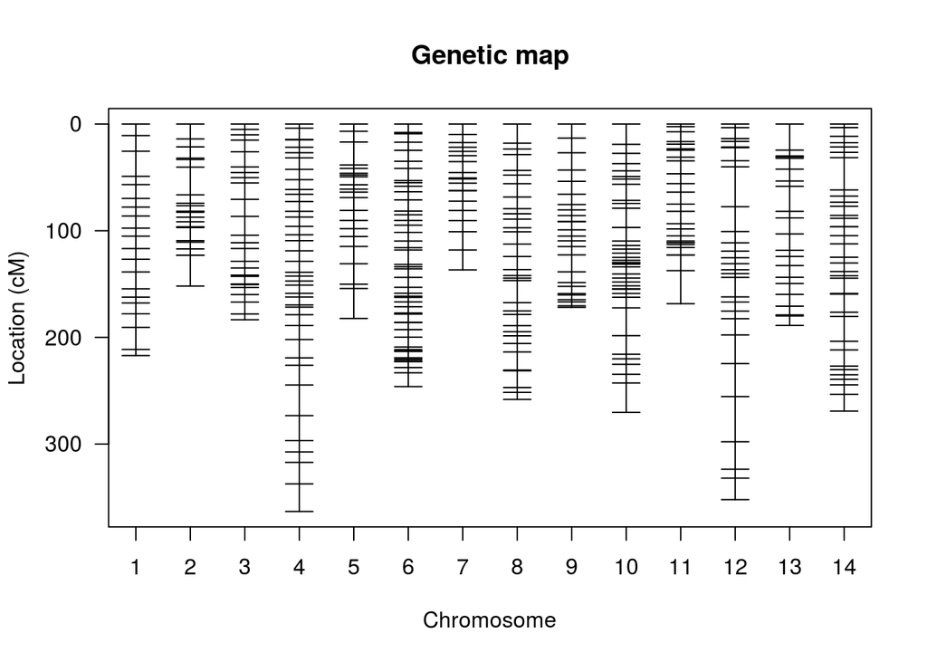

```r
plot.map(meus_dados)
```

## Dados fenotípicos

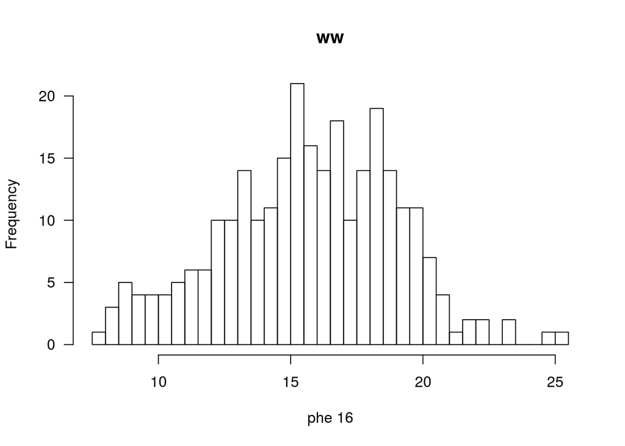

```r
plot.pheno(meus_dados, 16)
```

Continuando com as análises de mapeamento de QTLs, utilizaremos o mesmo fenótipo (**ww**). Vale relembrar que a porcentagem de dados fenotípicos é de 96,2% e possui uma distribuição próxima da Normal.

## Dados genotípicos

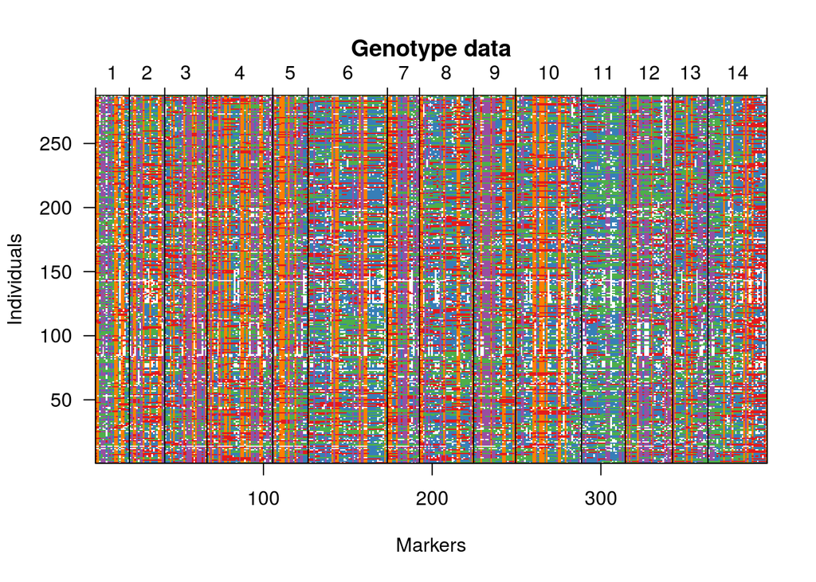

```r
geno.image(meus_dados)
```

Pela função *geno.image()*, para os marcadores codominantes, os genótipos AA, AB e BB são apresentados nas cores vermelho, azul e verde, respectivamente. Já para os marcadores dominantes, os genótipos “não BB” e “não AA” são apresentados nas cores lilás e laranja, respectivamente. Os dados perdidos são apresentados na cor branca.

A partir deste gráfico, pode-se verificar o predomínio dos marcadores em cada cromossomo. Por exemplo, embora os marcadores dominantes estejam distribuídos por todo o genoma, há um predomínio dos marcadores codominantes no cromossomo 11.

### Mapeamento por intervalo composto

Esta abordagem já foi realizada anteriormente e serão apresentados apenas os resultados finais.

**Valor de thresholds**

```r
permut.cim[1:5]
```

```
##       [,1]
## [1,] 2.822
## [2,] 4.216
## [3,] 3.203
## [4,] 4.893
## [5,] 5.990
## attr(,"class")
## [1] "scanoneperm" "matrix"
```

```r
summary(permut.cim, alpha=0.05)
```

```
## LOD thresholds (1000 permutations)
##    [,1]
## 5% 6.19
```

O valor crítico obtido a partir desta distribuição, considerando um percentil de 95%, foi de 6.19.

**Detecção de QTLs**

```r
summary(mapa.cim)
```

```
##           chr   pos    lod
## AA173C      1 154.4  1.232
## BD99        2 123.0  3.915
## c3.loc102   3 102.0  3.350
## MgSTS455    4 273.3  2.346
## AA268       5  90.4  2.743
## c6.loc51    6  51.0  1.227
## CB162       7  35.2  1.329
## AAT296      8 167.5  1.446
## BB176       9  85.8  1.337
## AAT374     10 125.1 10.386
## c11.loc69  11  69.0  3.367
## CB216      12  13.6  0.507
## c13.loc97  13  97.0  1.759
## c14.loc94  14  94.0  1.850
```

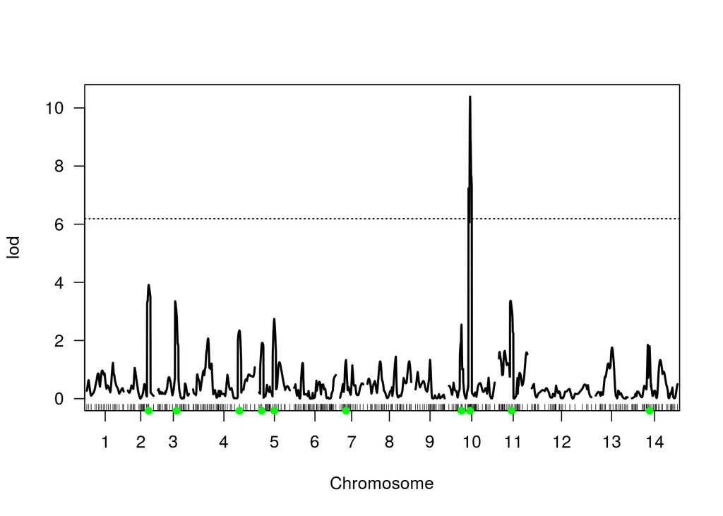

```r
plot(mapa.cim)
add.cim.covar(mapa.cim, col="green")
abline(h=6.19, lty=3)
```

Para este conjunto de dados, considerando 10 covariáveis no modelo e um valor de threshold de 6.19, foi detectado um único QTL no cromossomo 10.

**Intervalos dos QTLs**

```r
lodint(mapa.cim, chr=10, drop=1.8, expandtomarkers=T)
```

```
##          chr   pos    lod
## BC498     10 121.1  6.058
## AAT374    10 125.1 10.386
## MgSTS388  10 129.8  8.312
```

**Efeitos dos QTLs**

```r
summary(ajuste.cim)
```

```
##
##      fitqtl summary
##
## Method: multiple imputation
## Model:  normal phenotype
## Number of observations : 276
##
## Full model result
## ----------------------------------
## Model formula: y ~ Q1
##
##        df     SS      MS  LOD  %var Pvalue(Chi2) Pvalue(F)
## Model   2  201.9 100.972 4.92 7.881    1.203e-05 1.361e-05
## Error 273 2360.6   8.647
## Total 275 2562.5
##
##
## Estimated effects:
## -----------------
##               est      SE       t
## Intercept 20.1751  0.1779 113.378
## 10@125.1a  1.2699  0.2643   4.805
## 10@125.1d  0.2680  0.3597   0.745
```

Segue abaixo uma tabela com informação do QTL identificado pelo mapeamento por intervalo composto.

| Cromossomo | Posição | Marcador | LOD | $r^2$ | Efeito aditivo | Efeito de dominância |
| --- | --- | --- | --- | --- | --- | --- |
| 10 | 125.1 | AAT374 | 10.386 | 7.881 | 1.2699 $\pm$ 0.2643 | 0.2680 $\pm$ 0.3597 |

Abaixo será apresentado o mapa genético indicando a posição deste QTL.

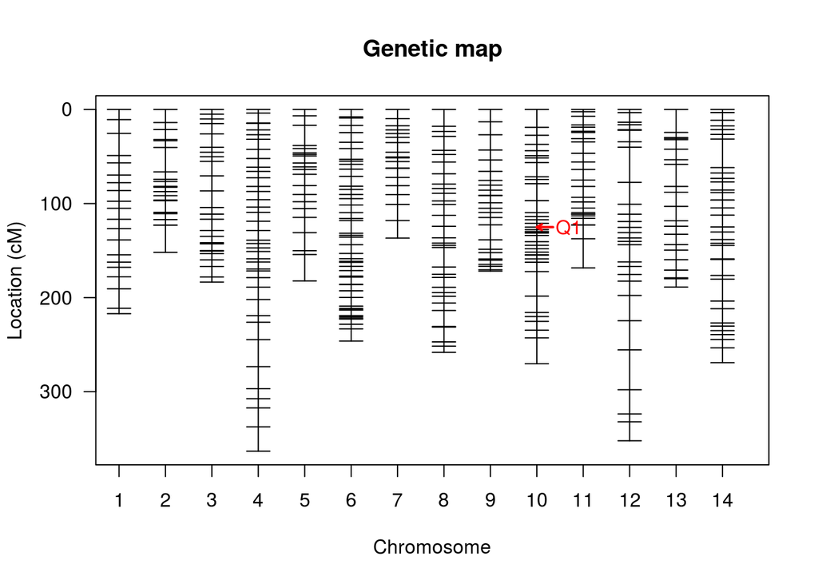

```r
plot(qtl.cim)
```

Como sugestão do modelo de partida para o mapeamento de múltiplos intervalos, serão empregados os QTLs detectados no método CIM considerando um *threshold* menos conservativo (3.00).

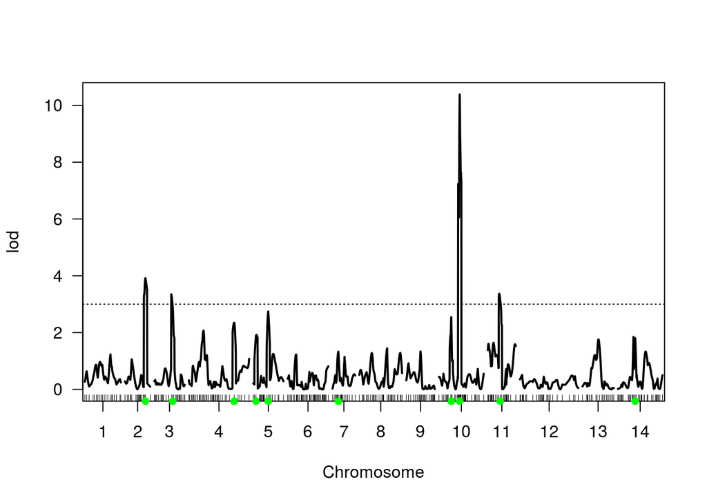

```r
plot(mapa.cim)
add.cim.covar(mapa.cim, col="green")
abline(h=3.0, lty=3)
```

Com esse *threshold*, serão considerados os QTLs nos cromossomos 2, 3, 10 e 11.

### Mapeamento em duas dimensões

Outro tipo de mapeamento é o mapeamento em duas dimensões, o qual permite avaliar modelos com dois QTLs simultaneamente e a interação entre eles.

```r
mapa.2dim <- scantwo(prob.cond, pheno.col=16, method="hk", verbose=FALSE, n.cluster=7)
```

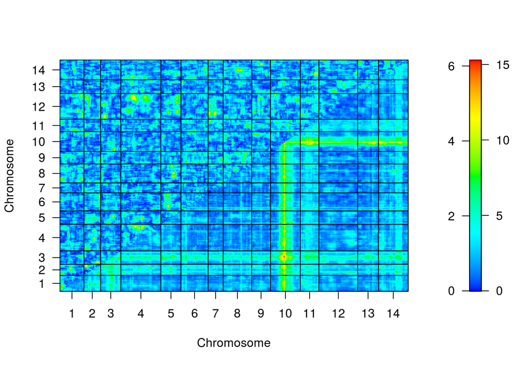

```r
plot(mapa.2dim)
```

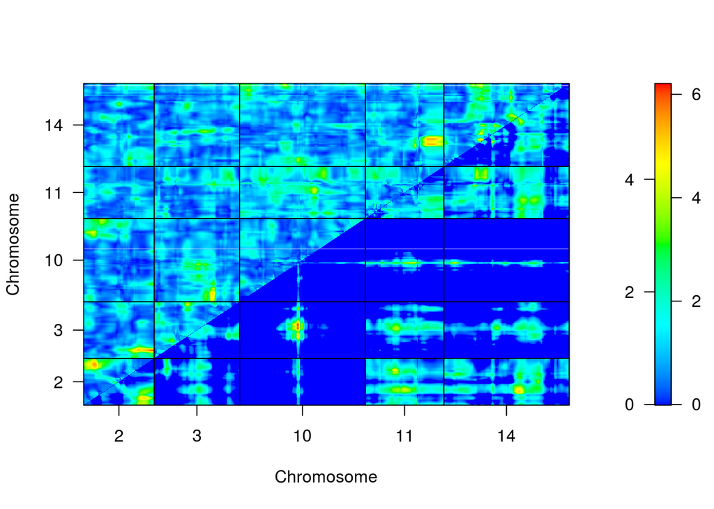

```r
plot(mapa.2dim, chr=c(2, 3, 10, 11, 14), lower="cond-int")
```

Com esse método, serão considerados os QTLs nos cromossomos 2, 3, 10, 11 e 14.

### Mapeamento de Múltiplos Intervalos

O Mapeamento de Múltiplos Intervalos (MIM) considera simultaneamente múltiplos QTLs no modelo, e utiliza da comparação de diversos modelos para selecionar o mais adequado para cada situação (número de QTLs considerados e inclusão ou não de interação entre eles). Este modelo tem como vantagens: combinar alta precisão com elevado poder estatístico; permitir a inclusão de epistasia; permitir o estudo da arquitetura genética dos caracteres quantitativos; permitir estimar o número, posição, efeitos e interação entre QTLs; e permitir estimar os *breeding values* (seleção assistida).

Para formulação do modelo inicial a ser avaliado no MIM, serão considerando os resultados tanto do método CIM quanto do mapeamento em duas dimensões. Desta forma, serão incluídos os QTLs detectados nos cromossomos 2, 3, 10 e 11 (os quais estiveram presentes em ambos métodos). No processo de mapeamento será verificado a significância de cada um desses QTLs. Inicialmente, serão considerados apenas os efeitos aditivos dos QTLs.

**Ajuste e comparação de modelos**

```r
modelo1 <- makeqtl(prob.cond, chr=c(2, 3, 10, 11),
                   pos=c(123.0, 169.0, 125.1, 163.0), what="prob")
modelo1
```

```
##   QTL object containing genotype probabilities.
##
##        name chr    pos n.gen
## Q1  2@123.0   2 123.00     3
## Q2  3@169.0   3 169.00     3
## Q3 10@125.1  10 125.07     3
## Q4 11@163.0  11 163.00     3
```

```r
y <- meus_dados$pheno[,16]
ajuste.mod1 <- fitqtl(prob.cond, qtl=modelo1, formula=y~Q1+Q2+Q3+Q4, method="hk")
summary(ajuste.mod1)
```

```
##
##      fitqtl summary
##
## Method: Haley-Knott regression
## Model:  normal phenotype
## Number of observations : 276
##
## Full model result
## ----------------------------------
## Model formula: y ~ Q1 + Q2 + Q3 + Q4
##
##        df     SS     MS   LOD  %var Pvalue(Chi2) Pvalue(F)
## Model   8  378.8 47.348 9.587 14.78    5.336e-07 8.125e-07
## Error 267 2183.7  8.179
## Total 275 2562.5
##
##
## Drop one QTL at a time ANOVA table:
## ----------------------------------
##          df Type III SS   LOD  %var F value Pvalue(Chi2) Pvalue(F)
## 2@123.0   2       78.22 2.109 3.052   4.782        0.008   0.00911 **
## 3@169.0   2       42.01 1.142 1.639   2.568        0.072   0.07859 .
## 10@125.1  2      182.95 4.822 7.139  11.184        0.000  2.17e-05 ***
## 11@163.0  2       43.67 1.187 1.704   2.670        0.065   0.07113 .
## ---
## Signif. codes:  0 '***' 0.001 '**' 0.01 '*' 0.05 '.' 0.1 ' ' 1
```

A partir do ajuste do modelo 1, pode-se observar que dois QTLs foram não significativos (QTLs nos cromossomos 3 e 11). Desta forma, um novo modelo será formulado considerando apenas os QTLs nos cromossomos 2 e 10.

```r
modelo2 <- dropfromqtl(modelo1, chr=c(3, 11), pos=c(169.0, 163.0))

ajuste.mod2 <- fitqtl(prob.cond, qtl=modelo2, formula=y~Q1+Q2, method="hk")
summary(ajuste.mod2)
```

```
##
##      fitqtl summary
##
## Method: Haley-Knott regression
## Model:  normal phenotype
## Number of observations : 276
##
## Full model result
## ----------------------------------
## Model formula: y ~ Q1 + Q2
##
##        df     SS     MS   LOD  %var Pvalue(Chi2) Pvalue(F)
## Model   4  294.5 73.633 7.318 11.49    8.588e-07 1.082e-06
## Error 271 2268.0  8.369
## Total 275 2562.5
##
##
## Drop one QTL at a time ANOVA table:
## ----------------------------------
##          df Type III SS   LOD  %var F value Pvalue(Chi2) Pvalue(F)
## 2@123.0   2       92.23 2.389 3.599   5.511        0.004   0.00451 **
## 10@125.1  2      220.82 5.568 8.617  13.193        0.000  3.41e-06 ***
## ---
## Signif. codes:  0 '***' 0.001 '**' 0.01 '*' 0.05 '.' 0.1 ' ' 1
```

```r
eff.mod2 <-  fitqtl(prob.cond, qtl=modelo2, formula=y~Q1+Q2, method="hk", dropone=FALSE, get.ests=TRUE)
summary(eff.mod2)
```

```
##
##      fitqtl summary
##
## Method: Haley-Knott regression
## Model:  normal phenotype
## Number of observations : 276
##
## Full model result
## ----------------------------------
## Model formula: y ~ Q1 + Q2
##
##        df     SS     MS   LOD  %var Pvalue(Chi2) Pvalue(F)
## Model   4  294.5 73.633 7.318 11.49    8.588e-07 1.082e-06
## Error 271 2268.0  8.369
## Total 275 2562.5
##
##
## Estimated effects:
## -----------------
##               est      SE       t
## Intercept 20.1160  0.1767 113.820
## 2@123.0a   0.8004  0.2456   3.259
## 2@123.0d   0.3696  0.3676   1.006
## 10@125.1a  1.3472  0.2631   5.121
## 10@125.1d  0.2116  0.3549   0.596
```

**Reposicionando os QTLs**

```r
modelo3 <- refineqtl(prob.cond, qtl=modelo2, formula=y~Q1+Q2, verbose=FALSE, method="hk")
modelo3
```

```
##   QTL object containing genotype probabilities.
##
##        name chr    pos n.gen
## Q1  2@101.0   2 101.00     3
## Q2 10@125.1  10 125.07     3
```

| Cromossomo | Antes do reposicionamento | Depois do reposicionamento |
| --- | --- | --- |
| 2 | 123.00 | 101.00 |
| 10 | 125.07 | 125.07 |

```r
ajuste.mod3 <- fitqtl(prob.cond, qtl=modelo3, formula=y~Q1+Q2, method="hk", dropone=TRUE, get.ests=TRUE)
summary(ajuste.mod3)
```

```
##
##      fitqtl summary
##
## Method: Haley-Knott regression
## Model:  normal phenotype
## Number of observations : 276
##
## Full model result
## ----------------------------------
## Model formula: y ~ Q1 + Q2
##
##        df     SS     MS   LOD  %var Pvalue(Chi2) Pvalue(F)
## Model   4  300.6 75.141 7.477 11.73     6.07e-07 7.689e-07
## Error 271 2261.9  8.347
## Total 275 2562.5
##
##
## Drop one QTL at a time ANOVA table:
## ----------------------------------
##          df Type III SS   LOD  %var F value Pvalue(Chi2) Pvalue(F)
## 2@101.0   2       98.26 2.549 3.835   5.886        0.003   0.00314 **
## 10@125.1  2      200.29 5.085 7.816  11.998        0.000  1.02e-05 ***
## ---
## Signif. codes:  0 '***' 0.001 '**' 0.01 '*' 0.05 '.' 0.1 ' ' 1
##
##
## Estimated effects:
## -----------------
##                est       SE       t
## Intercept 20.15758  0.17545 114.890
## 2@101.0a   0.86758  0.25286   3.431
## 2@101.0d   0.01995  0.39830   0.050
## 10@125.1a  1.27138  0.26055   4.880
## 10@125.1d  0.23400  0.35503   0.659
```

Realizando o reposicionamento do QTL, o LOD *score* do modelo 3 aumentou de 7.32 para 7.48, verificando um melhor ajuste deste modelo em relação ao modelo anterior.

**Intervalos dos QTLs**

```r
# QTL no cromossomo 2
find.marker(meus_dados, 2, 101.00)
```

```
## [1] "MgSTS589"
```

```r
lodint(modelo3, drop=1.5, qtl.index=1, expandtomarkers=T)
```

```
##           chr    pos   lod
## CB280       2  76.57 0.330
## c2.loc101   2 101.00 2.549
## CA279       2 151.85 2.057
```

```r
# QTL no cromossomo 10
lodint(modelo3, drop=1.5, qtl.index=2, expandtomarkers=T)
```

```
##          chr   pos   lod
## AAT278    10 109.7 2.991
## AAT374    10 125.1 5.085
## MgSTS388  10 129.8 3.462
```

Tabela referente ao mapeamento por intervalo composto

| Cromossomo | Identificação | Posição | LOD | Amplitude CIM |
| --- | --- | --- | --- | --- |
| 10 | AAT374 | 125.07 | 10.3865 | 8.7397 |

Tabela referente ao mapeamento de múltipos intervalos

| Cromossomo | Identificação | Posição | LOD | Amplitude MIM |
| --- | --- | --- | --- | --- |
| 2 | MgSTS589 | 101.00 | 2.5486 | 75.2814 |
| 10 | AAT374 | 125.07 | 5.0849 | 20.1040 |

**Teste de interações**

```r
addint(prob.cond, qtl=modelo3, formula=y~Q1+Q2, method="hk")
```

```
## Method: Haley-Knott regression
## Model:  normal phenotype
## Model formula: y ~ Q1 + Q2
##
## Add one pairwise interaction at a time table:
## --------------------------------------------
##                  df Type III SS     LOD   %var F value Pvalue(Chi2)
## 2@101.0:10@125.1  4       3.493 0.09263 0.1363  0.1033         0.98
##                  Pvalue(F)
## 2@101.0:10@125.1     0.981
```

Pela função *addint()* verifica-se a não significância da interação entre os dois QTLs considerados no modelo.

**Adição de novos QTLs**

A função *addqtl()* busca adicionar novos QTLs estritamente de forma aditiva.

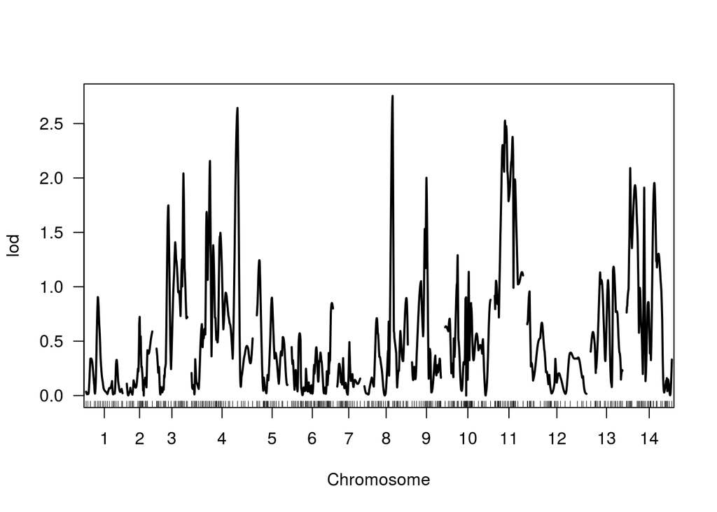

```r
modelo4 <- addqtl(prob.cond, qtl=modelo3, formula=y~Q1+Q2, method="hk")
plot(modelo4)
```

```r
max(modelo4)
```

```
##        chr pos  lod
## AAT296   8 167 2.75
```

O próximo maior pico foi no cromossomo 8. No entanto, como o menor valor de *threshold* considerado foi de 3.0 e o pico atingiu um valor de 2.75, este efeito não será incluído no modelo.

Usando a função *addpair()*, realiza-se a procura da adição de novos QTLs, no entanto com uma busca em duas dimensões (testando aditividade e interação simultaneamente).

```r
modelo5 <- addpair(prob.cond, qtl=modelo3, formula=y~Q1+Q2, method="hk", verbose=FALSE)
```

```r
summary(modelo5)
```

```
##         pos1f pos2f lod.full lod.fv1 lod.int     pos1a pos2a lod.add
## c1 :c1     11    35     4.07  2.0454   1.809        44    66    2.26
## c1 :c2     26    21     5.05  3.0268   3.426        70    76    1.63
## c1 :c3     74   160     5.50  1.0713   2.298        70   160    3.20
## c1 :c4     73   127     4.58  0.0596   1.083        70   273    3.49
## c1 :c5     75   115     2.69  0.6647   0.511        70    15    2.18
## c1 :c6     69   156     3.59  0.6807   1.707        70   246    1.88
## c1 :c7     69   112     4.02  1.4165   2.720        70    72    1.30
## c1 :c8    202   167     4.64  0.5735   1.106        70   167    3.54
## c1 :c9     99    86     5.22  2.3847   2.320        70    86    2.90
## c1 :c10    45   226     5.49  2.5831   3.360        70   140    2.13
## c1 :c11    97    99     5.91  1.8805   2.360        70    61    3.55
## c1 :c12   191   328     4.15  1.9060   2.323        70    12    1.83
## c1 :c13   121    56     4.05  1.1130   1.955        70   135    2.10
## c1 :c14    50    37     5.17  1.3592   1.873        70    22    3.30
## c2 :c2     26   137     4.02  2.5809   1.969        66    68    2.05
## c2 :c3     88   160     4.83  0.3991   1.695        76   160    3.13
## c2 :c4     94   273     6.84  2.3294   3.642        76   273    3.20
## c2 :c5     85   105     5.49  3.4606   3.448        76    16    2.04
## c2 :c6    151   205     4.97  2.0641   3.453        76   238    1.52
## c2 :c7     85    17     3.87  1.2627   2.682        76    72    1.19
## c2 :c8    139    23     4.79  0.7186   1.288        76   167    3.50
## c2 :c9    151    54     5.10  2.2643   2.347        76    86    2.75
## c2 :c10    38   270     4.32  1.4041   2.204       151    74    2.11
## c2 :c11    77   106     5.60  1.5720   2.318        76    68    3.28
## c2 :c12   151    23     3.69  1.4421   2.020        76    13    1.67
## c2 :c13     0    17     3.54  0.5976   1.610       151   135    1.93
## c2 :c14    77   162     5.19  1.3780   2.374        83    22    2.82
## c3 :c3     71   173     6.03  1.5991   1.599        72    72    4.43
## c3 :c4    160   273     6.68  2.1681   1.780       160   273    4.90
## c3 :c5     71    28     6.11  1.6812   2.754       160    12    3.36
## c3 :c6     66   135     4.60  0.1704   1.418       160   242    3.18
## c3 :c7    125    81     4.13 -0.3034   1.473       160    72    2.65
## c3 :c8    160   167     5.11  0.6824   0.438       160   167    4.67
## c3 :c9     15    58     6.04  1.6092   1.992       160    86    4.05
## c3 :c10    70   122     6.30  1.8713   3.049       160    74    3.25
## c3 :c11     0    47     6.72  2.2912   2.029       160    61    4.69
## c3 :c12   160    47     4.39 -0.0421   1.177       160    12    3.21
## c3 :c13   111    67     5.23  0.8024   1.951        70    56    3.28
## c3 :c14    70   197     6.15  1.7235   2.105       160   167    4.05
```

[output cut: 157 more lines]

```
## c10:c10  0.0000
## c10:c11  0.0190
## c10:c12 -0.3932
## c10:c13 -0.4722
## c10:c14  0.0600
## c11:c11  0.0405
## c11:c12 -0.5145
## c11:c13 -0.2342
## c11:c14  0.5895
## c12:c12  0.0000
## c12:c13 -0.7470
## c12:c14 -0.8603
## c13:c13  0.6397
## c13:c14 -0.4960
## c14:c14  0.0000
```

Pela função *summary()*, são apresentados os resultados considerando o modelo completo (considerando interação) versus o modelo aditivo. As cinco primeiras colunas são referentes ao modelo completo e as quatro últimas colunas são referentes ao modelo aditivo. O LODint representa a evidência de uma interação, o LODfv1 representa a evidência para um segundo QTL, permitindo para uma interação e o LODav1 representa um segundo QTL, assumindo os dois serem aditivos. Pode-se verificar que alguns valores de LODint são maiores que 3, no entanto estes valores não foram muito representativos para serem incluídos no modelo.

**Modelo Final**

Desta forma, o modelo final considerado será o modelo 3, com dois QTLs (nos cromossomos 2 e 10). Segue abaixo uma tabela com informação dos QTLs identificados pelo Mapeamento de Múltiplos Intervalos.

| Cromossomo | Marcador | LOD | $r^2$ | Efeito aditivo | Efeito de dominância |
| --- | --- | --- | --- | --- | --- |
| 2 | MgSTS589 | 2.5486 | 3.835 | 0.86758 $\pm$ 0.2529 | 0.01995 $\pm$ 0.3983 |
| 10 | AAT374 | 5.0849 | 7.816 | 1.27138 $\pm$ 0.2605 | 0.23400 $\pm$ 0.3550 |

Abaixo será apresentado um gráfico com os perfils de LODs para cada um dos QTLs considerados.

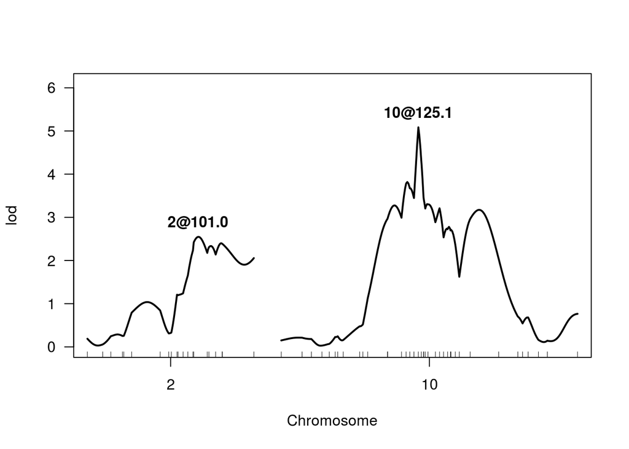

```r
plotLodProfile(modelo3)
```

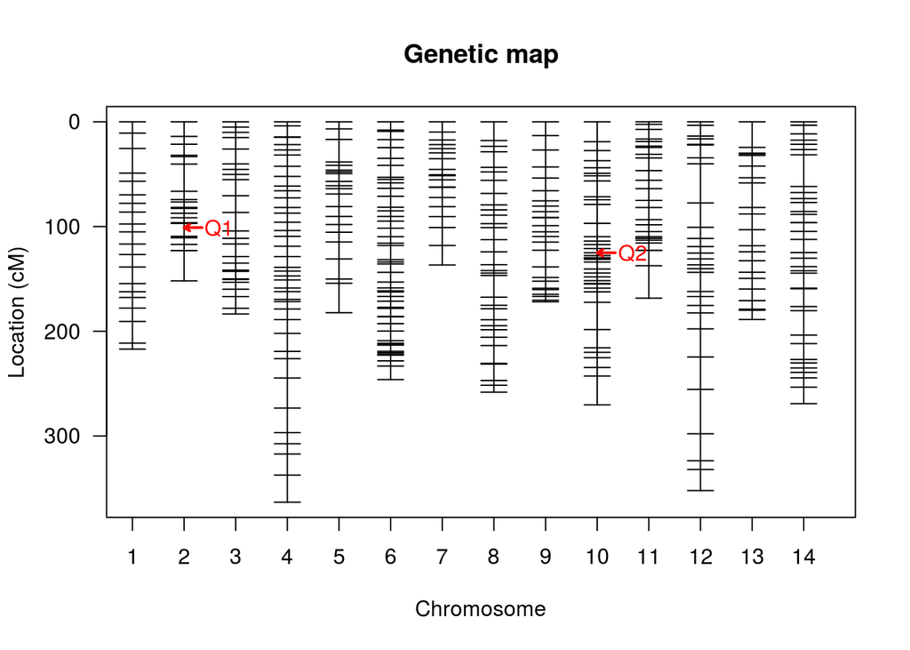

```r
plot(modelo3)
```

### Seleção por stepwise

Apenas de forma ilustrativa, será apresentado a busca automática do melhor modelo, implementado no pacote R/qtl, pela função *stepwiseqtl()*. Essa função faz uma busca de modelos agregando e eliminando sequencialmente QTLs de forma aditiva e interações entre QTLs. Posteriormente ela compara cada um dos modelos com LODs penalizados. Desta forma obtêm-se um balanço entre as taxas de falso positivo e falso negativo - pois modelos com maior número de QTLs tendem a ter maiores LODs, no entanto são mais complexos - e seleciona-se o melhor modelo.

Na primeira etapa são estabelecidos os valores de *threshold* dos LODs penalizados, por meio de permutações. Esses *thresholds* são necessários na função *stepwiseqtl()*.

```r
set.seed(85842518)
permuta <- scantwopermhk (prob.cond, pheno.col=16, n.perm=500)
```

```r
set.seed(85842518)
permutb <- scantwopermhk(prob.cond, pheno.col=16, n.perm=500)
```

```r
permut.hk <- c(permuta, permutb)
```

```r
summary(permut.hk)
```

```
## fl (1000 permutations)
##     full  fv1  int  add  av1  one
## 5%  9.40 7.31 6.24 6.56 3.63 3.76
## 10% 8.98 7.02 5.89 6.17 3.38 3.45
```

```r
penalidades <- calc.penalties(permut.hk, alpha=0.05)
penalidades
```

```
##  main heavy light
## 3.762 6.242 3.552
```

```r
mapa.step <- stepwiseqtl(prob.cond, max.qtl=10, penalties=penalidades, verbose=FALSE,
                         keeplodprofile=TRUE, keeptrace=TRUE)
```

```r
mapa.step
```

```
##   QTL object containing genotype probabilities.
##
##        name chr    pos n.gen
## Q1 10@125.1  10 125.07     3
##
##   Formula: y ~ Q1
##
##   pLOD:  1.166
```

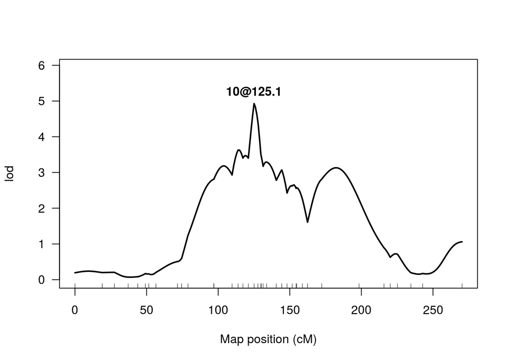

```r
plotLodProfile(mapa.step)
```

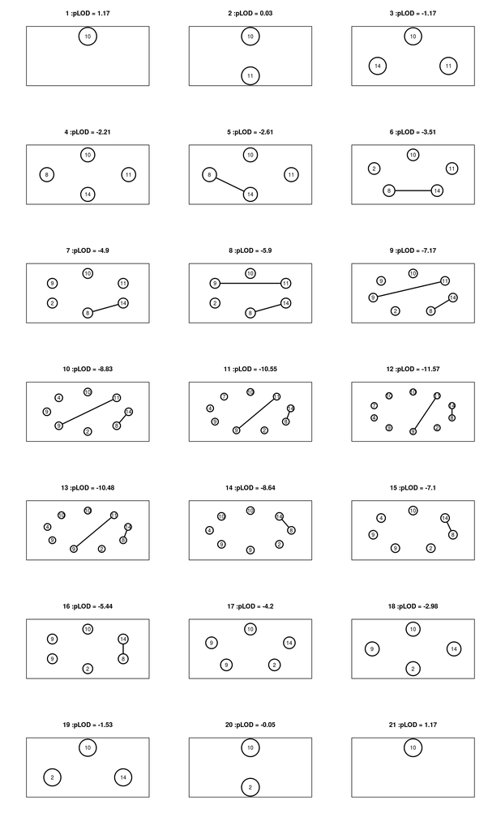

```r
passos <- attr(mapa.step, "trace")

par(mfrow=c(7,3))
for(i in seq(along=passos)){
  plotModel(passos[[i]], chronly=TRUE,
            main=paste(i, ":pLOD =",
                       round(attr(passos[[i]], "pLOD"), 2)))
}
```

Como resultado desta função, foi selecionado o modelo que considera um único QTL no cromossomo 10, na posição 125.07.A partir do gráfico de passos, pode-se obsevar todos os modelos que foram testados nesta função, até considerar modelos com 10 QTLs. Quando comparados todos os modelos, o modelo que considera um único QTL no cromossomo 10 obteve o maior valor de LOD penalizado (1,17) e por tanto é o modelo final para este método.

### Comparação dos métodos

**Método manual versus método automático**

Serão comparados os resultados obtidos com ambas metodologias, a seleção e comparação de modelos de forma manual com a forma automatizada empregada na função *stepwiseqtl()*.

Pelo método manual, o modelo selecionado foi:

$y_{j} = \mu + \beta^*_{1}x^{*}_{1j} + \beta^*_{2}x^*_{2j} + \varepsilon_{j}$

Pelo método automático, o modelo selecionado foi:

$y_{j} = \mu + \beta^*_{1}x^*_{1j} + \varepsilon_{j}$

Onde,

$\quad y_{j} =$ valor fenotípico do indivíduo $j$

$\quad \mu =$ intercepto

$\quad \beta_{r} =$ efeito marginal do QTL $r$

$\quad x^*_{jr} =$ variável indicadora do genótipo do QTL $r$

$\quad \varepsilon_{j} \sim N(0, \sigma^{2})$

Apesar dos métodos resultarem em modelos diferentes, o modelo considerado foi o obtido de forma manual, com dois QTLs.

**Mapeamento CIM versus mapeamento MIM**

| Método | N. QTLs | Cromossomo | Marcador | Posição | LOD | Amplitude do QTL | $r^2$ |
| --- | --- | --- | --- | --- | --- | --- | --- |
| CIM | 1 | 10 | AAT374 | 125.07 | 10.3865 | 8.7397 | 7.881 |
| MIM | 2 | 2 | MgSTS589 | 101.00 | 2.5486 | 75.2814 | 3.835 |
|  |  | 10 | AAT374 | 125.07 | 5.0849 | 20.1040 | 7.816 |

Como demonstrado na tabela, houve diferenças nos resultados obtidos entre as duas metodologias. No método CIM foi detectado um QTl, no cromossomo 10, mas para o método MIM foram detectados dois QTLs, nos cromossomos 2 e 10. Pode-se ainda verificar que o QTL detectado no cromossomo 10 é o mesmo para ambos métodos (marcador AAT374), com a mesma posição (125,0682), porém com maior valor de LOD e menor amplitude no método CIM. Esperava-se que um maior LOD e uma menor amplitude fosse obtido pelo método MIM.

```r
save.image("Lista11fin.Rdata")
```